# Survival models

## Objectives

1. Exploration
2. Determine model to use for binomial outcome variable (number of successes in n trials)
3. Evaluate model:
- fit
- qqplots
- outliers
- residuals vs temp
1. Test for interaction with land cover and temp
2. Produce graphs of relationship

## Exploration first

```r
ggplot(filter(s, Species == "WEBL"),aes(x = habitat, y = p_eggs_hatched)) + geom_boxplot()

ggplot(filter(s, Species == "WEBL"),aes(x = meanmaxt_inc, y = p_eggs_hatched)) + geom_point() + facet_wrap(~habitat)
# ggplot(filter(s, Species == "WEBL"),aes(x = meanmint_inc, y = p_eggs_hatched)) + geom_point() + facet_wrap(~habitat)

ggplot(filter(s, Species == "WEBL"),aes(x = meanmaxt_nest, y = p_nest_fledged)) + geom_point() + facet_wrap(~habitat)

ggplot(filter(s, Species == "WEBL"),aes(x = meanmaxt_nestpd, y = p_eggs_fledged)) + geom_point() + facet_wrap(~habitat)
```

```r
ggplot(filter(s, Species == "TRES"),aes(x = habitat, y = p_eggs_hatched)) + geom_boxplot()
ggplot(filter(s, Species == "TRES"),aes(x = habitat, y = p_nest_fledged)) + geom_boxplot()
ggplot(filter(s, Species == "TRES"),aes(x = habitat, y = p_eggs_fledged)) + geom_boxplot()


ggplot(filter(s, Species == "TRES"),aes(x = meanmaxt_inc, y = p_eggs_hatched)) + geom_point() + facet_wrap(~habitat)
# ggplot(filter(s, Species == "TRES"),aes(x = meanmint_inc, y = p_eggs_hatched)) + geom_point() + facet_wrap(~habitat)

ggplot(filter(s, Species == "TRES"),aes(x = meanmaxt_nest, y = p_nest_fledged)) + geom_point() + facet_wrap(~habitat)

ggplot(filter(s, Species == "TRES"),aes(x = meanmaxt_nestpd, y = p_eggs_fledged)) + geom_point() + facet_wrap(~habitat)
```

## Using glmer with family = “binomial”

### WEBL

#### Incubation model

```r
s_inc_WEBL <- glm(cbind(eggs_hatched,clutch_size - eggs_hatched) ~ meanmaxt_inc_scaled * habitat + meanmint_inc_scaled * habitat + juliandate_inc_scaled + year_fct + site,
               family = binomial(link = "logit"),
               data = dplyr::filter(s,
                                    Species == "WEBL",
                                    !is.na(eggs_hatched),
                                    !is.na(clutch_size)) %>%
                 mutate(across(c(meanmaxt_inc,meanmint_inc,juliandate_inc),
                               ~ scale(.x)[,1],
                               .names = "{.col}_scaled")
                      )
               )
```

Using site as a random effect results in a singular fit, so I left it as a fixed effect.

```r
summary(s_inc_WEBL)
```

```r
data = dplyr::filter(s,
                                    Species == "WEBL",
                                    !is.na(eggs_hatched),
                                    !is.na(clutch_size)) %>%
                 mutate(across(c(meanmaxt_inc,meanmint_inc,juliandate_inc),
                               ~ scale(.x)[,1],
                               .names = "{.col}_scaled")
                      )

mean_temp <- mean(data %>% pull(meanmaxt_inc),na.rm = TRUE)
sd_temp <- sd(data %>% pull(meanmaxt_inc),na.rm = TRUE)


temp_trans <- trans_new("temp_trans",
                          transform = function(x){(x * sd_temp) + mean_temp},
                           inverse = function(x){x})

samp <- s_inc_WEBL$data %>% group_by(habitat) %>% summarize(count = n())
# samp %>% gt() %>% gtsave("../figures/ss_webl.html")


dat_text <- data.frame(
label = paste("N =",samp$count),
  group   = factor(samp$habitat)
)



(pl <- predict_response(s_inc_WEBL,terms = c("meanmaxt_inc_scaled [all]","habitat"),bias_correction = TRUE,margin = "empirical") %>%
   plot(line_size = 1.5,alpha = .2,show_data = TRUE,limit_range = TRUE) +
   theme_classic() +
   facet_wrap(~ group, ncol = 2) +
    xlab("Mean daily max temp over incubation period (\u00b0C)") +
    ylab("Predicted proportion of eggs hatching") +
   scale_fill_viridis(discrete = TRUE) +
    scale_color_viridis(discrete = TRUE) +
    theme(text = element_text(size = 16)) +
    labs(title = "WEBL; linear max") +
   scale_x_continuous(trans = temp_trans,
                       breaks = c((20-mean_temp)/sd_temp,
                                  (25-mean_temp)/sd_temp,
                                  (30-mean_temp)/sd_temp,
                                  (35-mean_temp)/sd_temp,
                                  (40-mean_temp)/sd_temp#,
                                  #(45-mean_temp)/sd_temp
                                  ),
                       # breaks = c(20,30,40,50),
                       # labels = c("20","30","40","50"),
                       # limits = c((15-mean(g$meanmaxtempI,na.rm = TRUE))/sd(g$meanmaxtempI,na.rm = TRUE),
                       #            (55-mean(g$meanmaxtempI,na.rm = TRUE))/sd(g$meanmaxtempI,na.rm = TRUE))
                       # limits = c(18,5)
                       ) +
   # ylim(0,100) +
   geom_text(data = dat_text, mapping = aes(x = -Inf, y = .3,label = label),hjust = -.2,inherit.aes = FALSE) +
    theme(legend.position = "none")
 )
```

#### Nestling model

```r
s_nest_WEBL <- glm(cbind(nest_fledged,brood_size - nest_fledged) ~ meanmaxt_nest_scaled * habitat + meanmint_nest_scaled * habitat + juliandate_inc_scaled + year_fct + site,
               family = binomial(link = "logit"),
               data = dplyr::filter(s,
                                    Species == "WEBL",
                                    !is.na(nest_fledged),
                                    !is.na(brood_size)) %>%
                 mutate(across(c(meanmaxt_nest,meanmint_nest,juliandate_inc),
                               ~ scale(.x)[,1],
                               .names = "{.col}_scaled")
                      )
               )
```

Using site as a random effect results in a singular fit, so I left it as a fixed effect.

```r
summary(s_inc_WEBL)
```

```r
data = dplyr::filter(s,
                                    Species == "WEBL",
                                    !is.na(nest_fledged),
                                    !is.na(brood_size)) %>%
                 mutate(across(c(meanmaxt_nest,meanmint_nest,juliandate_inc),
                               ~ scale(.x)[,1],
                               .names = "{.col}_scaled")
                      )

mean_temp <- mean(data %>% pull(meanmaxt_nest),na.rm = TRUE)
sd_temp <- sd(data %>% pull(meanmaxt_nest),na.rm = TRUE)


temp_trans <- trans_new("temp_trans",
                          transform = function(x){(x * sd_temp) + mean_temp},
                           inverse = function(x){x})

samp <- s_nest_WEBL$data %>% group_by(habitat) %>% summarize(count = n())
# samp %>% gt() %>% gtsave("../figures/ss_webl.html")


dat_text <- data.frame(
label = paste("N =",samp$count),
  group   = factor(samp$habitat)
)



(pl <- predict_response(s_nest_WEBL,terms = c("meanmaxt_nest_scaled [all]","habitat"),bias_correction = TRUE,margin = "empirical") %>%
   plot(line_size = 1.5,alpha = .2,show_data = TRUE,limit_range = TRUE) +
   theme_classic() +
   facet_wrap(~ group, ncol = 2) +
    xlab("Mean daily max temp over nestling period (\u00b0C)") +
    ylab("Predicted proportion of nestlings fledging") +
   scale_fill_viridis(discrete = TRUE) +
    scale_color_viridis(discrete = TRUE) +
    theme(text = element_text(size = 16)) +
    labs(title = "WEBL; linear max") +
   scale_x_continuous(trans = temp_trans,
                       breaks = c((20-mean_temp)/sd_temp,
                                  (25-mean_temp)/sd_temp,
                                  (30-mean_temp)/sd_temp,
                                  (35-mean_temp)/sd_temp,
                                  (40-mean_temp)/sd_temp#,
                                  #(45-mean_temp)/sd_temp
                                  ),
                       # breaks = c(20,30,40,50),
                       # labels = c("20","30","40","50"),
                       # limits = c((15-mean(g$meanmaxtempI,na.rm = TRUE))/sd(g$meanmaxtempI,na.rm = TRUE),
                       #            (55-mean(g$meanmaxtempI,na.rm = TRUE))/sd(g$meanmaxtempI,na.rm = TRUE))
                       # limits = c(18,5)
                       ) +
   # ylim(0,100) +
   geom_text(data = dat_text, mapping = aes(x = -Inf, y = .3,label = label),hjust = -.2,inherit.aes = FALSE) +
    theme(legend.position = "none")
 )
```

#### Nest period model

```r
s_nestpd_WEBL <- glm(cbind(nest_fledged,clutch_size - nest_fledged) ~ meanmaxt_nestpd_scaled * habitat + meanmint_nestpd_scaled * habitat + juliandate_inc_scaled + year_fct + site,
               family = binomial(link = "logit"),
               data = dplyr::filter(s,
                                    Species == "WEBL",
                                    !is.na(nest_fledged),
                                    !is.na(clutch_size)) %>%
                 mutate(across(c(meanmaxt_nestpd,meanmint_nestpd,juliandate_inc),
                               ~ scale(.x)[,1],
                               .names = "{.col}_scaled")
                      )
               )
```

Using site as a random effect results in a singular fit, so I left it as a fixed effect.

```r
summary(s_nestpd_WEBL)
```

```r
mean_temp <- mean(s_nestpd_WEBL$data %>% pull(meanmaxt_nestpd),na.rm = TRUE)
sd_temp <- sd(s_nestpd_WEBL$data %>% pull(meanmaxt_nestpd),na.rm = TRUE)


temp_trans <- trans_new("temp_trans",
                          transform = function(x){(x * sd_temp) + mean_temp},
                           inverse = function(x){x})

samp <- s_nestpd_WEBL$data %>% group_by(habitat) %>% summarize(count = n())
# samp %>% gt() %>% gtsave("../figures/ss_webl.html")


dat_text <- data.frame(
label = paste("N =",samp$count),
  group   = factor(samp$habitat)
)



(pl <- predict_response(s_nestpd_WEBL,terms = c("meanmaxt_nestpd_scaled [all]","habitat"),bias_correction = TRUE) %>%
   plot(line_size = 1.5,alpha = .2,show_data = TRUE,limit_range = TRUE) +
   theme_classic() +
   facet_wrap(~ group, ncol = 2) +
    xlab("Mean daily max temp incubation to fledging (\u00b0C)") +
    ylab("Predicted proportion of eggs fledging") +
   scale_fill_viridis(discrete = TRUE) +
    scale_color_viridis(discrete = TRUE) +
    theme(text = element_text(size = 16)) +
    labs(title = "WEBL; linear max") +
   scale_x_continuous(trans = temp_trans,
                       breaks = c((20-mean_temp)/sd_temp,
                                  (25-mean_temp)/sd_temp,
                                  (30-mean_temp)/sd_temp,
                                  (35-mean_temp)/sd_temp,
                                  (40-mean_temp)/sd_temp#,
                                  #(45-mean_temp)/sd_temp
                                  ),
                       # breaks = c(20,30,40,50),
                       # labels = c("20","30","40","50"),
                       # limits = c((15-mean(g$meanmaxtempI,na.rm = TRUE))/sd(g$meanmaxtempI,na.rm = TRUE),
                       #            (55-mean(g$meanmaxtempI,na.rm = TRUE))/sd(g$meanmaxtempI,na.rm = TRUE))
                       # limits = c(18,5)
                       ) +
   # ylim(0,100) +
   geom_text(data = dat_text, mapping = aes(x = -Inf, y = .3,label = label),hjust = -.2,inherit.aes = FALSE) +
    theme(legend.position = "none")
 )
```

### TRES

#### Incubation model

```r
s_inc_TRES <- glm(cbind(eggs_hatched,clutch_size - eggs_hatched) ~ meanmaxt_inc_scaled * habitat + meanmint_inc_scaled * habitat + juliandate_inc_scaled + year_fct + site,
               family = binomial(link = "logit"),
               data = dplyr::filter(s,
                                    Species == "TRES",
                                    !is.na(eggs_hatched),
                                    !is.na(clutch_size),
                                    meanmaxt_inc < 50) %>%
                 mutate(across(c(meanmaxt_inc,meanmint_inc,juliandate_inc),
                               ~ scale(.x)[,1],
                               .names = "{.col}_scaled")
                      )
               )
```

Using site as a random effect results in a singular fit, so I left it as a fixed effect.

```r
summary(s_inc_TRES)
```

```r
data = s_inc_TRES$data

mean_temp <- mean(data %>% pull(meanmaxt_inc),na.rm = TRUE)
sd_temp <- sd(data %>% pull(meanmaxt_inc),na.rm = TRUE)


temp_trans <- trans_new("temp_trans",
                          transform = function(x){(x * sd_temp) + mean_temp},
                           inverse = function(x){x})

samp <- s_inc_TRES$data %>% group_by(habitat) %>% summarize(count = n())
# samp %>% gt() %>% gtsave("../figures/ss_TRES.html")


dat_text <- data.frame(
label = paste("N =",samp$count),
  group   = factor(samp$habitat)
)



(pl <- predict_response(s_inc_TRES,terms = c("meanmaxt_inc_scaled [all]","habitat"),bias_correction = TRUE) %>%
   plot(line_size = 1.5,alpha = .2,show_data = TRUE,limit_range = TRUE) +
   theme_classic() +
   facet_wrap(~ group, ncol = 2) +
    xlab("Mean daily max temp over incubation period (\u00b0C)") +
    ylab("Predicted proportion of eggs hatching") +
   scale_fill_viridis(discrete = TRUE) +
    scale_color_viridis(discrete = TRUE) +
    theme(text = element_text(size = 16)) +
    labs(title = "TRES; linear max") +
   scale_x_continuous(trans = temp_trans,
                       breaks = c((20-mean_temp)/sd_temp,
                                  (25-mean_temp)/sd_temp,
                                  (30-mean_temp)/sd_temp,
                                  (35-mean_temp)/sd_temp,
                                  (40-mean_temp)/sd_temp#,
                                  #(45-mean_temp)/sd_temp
                                  ),
                       # breaks = c(20,30,40,50),
                       # labels = c("20","30","40","50"),
                       # limits = c((15-mean(g$meanmaxtempI,na.rm = TRUE))/sd(g$meanmaxtempI,na.rm = TRUE),
                       #            (55-mean(g$meanmaxtempI,na.rm = TRUE))/sd(g$meanmaxtempI,na.rm = TRUE))
                       # limits = c(18,5)
                       ) +
   # ylim(0,100) +
   geom_text(data = dat_text, mapping = aes(x = -Inf, y = .3,label = label),hjust = -.2,inherit.aes = FALSE) +
    theme(legend.position = "none")
 )
```

#### Nestling model

```r
s_nest_TRES <- glm(cbind(nest_fledged,brood_size - nest_fledged) ~ meanmaxt_nest_scaled * habitat + meanmint_nest_scaled * habitat + juliandate_inc_scaled + year_fct + site,
               family = binomial(link = "logit"),
               data = dplyr::filter(s,
                                    Species == "TRES",
                                    !is.na(nest_fledged),
                                    !is.na(brood_size),
                                    meanmaxt_nest < 50) %>%
                 mutate(across(c(meanmaxt_nest,meanmint_nest,juliandate_inc),
                               ~ scale(.x)[,1],
                               .names = "{.col}_scaled")
                      )
               )
```

Using site as a random effect results in a singular fit, so I left it as a fixed effect.

```r
summary(s_inc_TRES)
```

```r
data = s_inc_TRES$data

mean_temp <- mean(data %>% pull(meanmaxt_nest),na.rm = TRUE)
sd_temp <- sd(data %>% pull(meanmaxt_nest),na.rm = TRUE)


temp_trans <- trans_new("temp_trans",
                          transform = function(x){(x * sd_temp) + mean_temp},
                           inverse = function(x){x})

samp <- s_nest_TRES$data %>% group_by(habitat) %>% summarize(count = n())
# samp %>% gt() %>% gtsave("../figures/ss_TRES.html")


dat_text <- data.frame(
label = paste("N =",samp$count),
  group   = factor(samp$habitat)
)



(pl <- predict_response(s_nest_TRES,terms = c("meanmaxt_nest_scaled [all]","habitat"),bias_correction = TRUE) %>%
   plot(line_size = 1.5,alpha = .2,show_data = TRUE,limit_range = TRUE) +
   theme_classic() +
   facet_wrap(~ group, ncol = 2) +
    xlab("Mean daily max temp over nestling period (\u00b0C)") +
    ylab("Predicted proportion of nestlings fledging") +
   scale_fill_viridis(discrete = TRUE) +
    scale_color_viridis(discrete = TRUE) +
    theme(text = element_text(size = 16)) +
    labs(title = "TRES; linear max") +
   scale_x_continuous(trans = temp_trans,
                       breaks = c((20-mean_temp)/sd_temp,
                                  (25-mean_temp)/sd_temp,
                                  (30-mean_temp)/sd_temp,
                                  (35-mean_temp)/sd_temp,
                                  (40-mean_temp)/sd_temp#,
                                  #(45-mean_temp)/sd_temp
                                  ),
                       # breaks = c(20,30,40,50),
                       # labels = c("20","30","40","50"),
                       # limits = c((15-mean(g$meanmaxtempI,na.rm = TRUE))/sd(g$meanmaxtempI,na.rm = TRUE),
                       #            (55-mean(g$meanmaxtempI,na.rm = TRUE))/sd(g$meanmaxtempI,na.rm = TRUE))
                       # limits = c(18,5)
                       ) +
   # ylim(0,100) +
   geom_text(data = dat_text, mapping = aes(x = -Inf, y = .3,label = label),hjust = -.2,inherit.aes = FALSE) +
    theme(legend.position = "none")
 )
```

#### Nest period model

```r
s_nestpd_TRES <- glm(cbind(nest_fledged,clutch_size - nest_fledged) ~ meanmaxt_nestpd_scaled * habitat + meanmint_nestpd_scaled * habitat + juliandate_inc_scaled + year_fct + site,
               family = binomial(link = "logit"),
               data = dplyr::filter(s,
                                    Species == "TRES",
                                    !is.na(nest_fledged),
                                    !is.na(clutch_size),
                                    meanmaxt_nestpd < 50) %>%
                 mutate(across(c(meanmaxt_nestpd,meanmint_nestpd,juliandate_inc),
                               ~ scale(.x)[,1],
                               .names = "{.col}_scaled")
                      )
               )
```

Using site as a random effect results in a singular fit, so I left it as a fixed effect.

```r
summary(s_nestpd_TRES)
```

```r
mean_temp <- mean(s_nestpd_TRES$data %>% pull(meanmaxt_nestpd),na.rm = TRUE)
sd_temp <- sd(s_nestpd_TRES$data %>% pull(meanmaxt_nestpd),na.rm = TRUE)


temp_trans <- trans_new("temp_trans",
                          transform = function(x){(x * sd_temp) + mean_temp},
                           inverse = function(x){x})

samp <- s_nestpd_TRES$data %>% group_by(habitat) %>% summarize(count = n())
# samp %>% gt() %>% gtsave("../figures/ss_TRES.html")


dat_text <- data.frame(
label = paste("N =",samp$count),
  group   = factor(samp$habitat)
)



(pl <- predict_response(s_nestpd_TRES,terms = c("meanmaxt_nestpd_scaled [all]","habitat")) %>%
   plot(line_size = 1.5,alpha = .2,show_data = TRUE,limit_range = TRUE) +
   theme_classic() +
   facet_wrap(~ group, ncol = 2) +
    xlab("Mean daily max temp incubation to fledging (\u00b0C)") +
    ylab("Predicted proportion of eggs fledging") +
   scale_fill_viridis(discrete = TRUE) +
    scale_color_viridis(discrete = TRUE) +
    theme(text = element_text(size = 16)) +
    labs(title = "TRES; linear max") +
   scale_x_continuous(trans = temp_trans,
                       breaks = c((20-mean_temp)/sd_temp,
                                  (25-mean_temp)/sd_temp,
                                  (30-mean_temp)/sd_temp,
                                  (35-mean_temp)/sd_temp,
                                  (40-mean_temp)/sd_temp#,
                                  #(45-mean_temp)/sd_temp
                                  ),
                       # breaks = c(20,30,40,50),
                       # labels = c("20","30","40","50"),
                       # limits = c((15-mean(g$meanmaxtempI,na.rm = TRUE))/sd(g$meanmaxtempI,na.rm = TRUE),
                       #            (55-mean(g$meanmaxtempI,na.rm = TRUE))/sd(g$meanmaxtempI,na.rm = TRUE))
                       # limits = c(18,5)
                       ) +
   # ylim(0,100) +
   geom_text(data = dat_text, mapping = aes(x = -Inf, y = .3,label = label),hjust = -.2,inherit.aes = FALSE) +
    theme(legend.position = "none")
 )
```

## Test for interaction with land cover and temp

### WEBL

#### Incubation model

```r
s_inc_WEBL <- glm(cbind(eggs_hatched,clutch_size - eggs_hatched) ~ meanmaxt_inc_scaled * habitat + meanmint_inc_scaled * habitat + juliandate_inc_scaled + year_fct + site,
               family = binomial(link = "logit"),
               data = dplyr::filter(s,
                                    Species == "WEBL",
                                    !is.na(eggs_hatched),
                                    !is.na(clutch_size)) %>%
                 mutate(across(c(meanmaxt_inc,meanmint_inc,juliandate_inc),
                               ~ scale(.x)[,1],
                               .names = "{.col}_scaled")
                      )
               )

s_inc_WEBL_addmax <- glm(cbind(eggs_hatched,clutch_size - eggs_hatched) ~ meanmaxt_inc_scaled + meanmint_inc_scaled * habitat + juliandate_inc_scaled + year_fct + site,
               family = binomial(link = "logit"),
               data = dplyr::filter(s,
                                    Species == "WEBL",
                                    !is.na(eggs_hatched),
                                    !is.na(clutch_size)) %>%
                 mutate(across(c(meanmaxt_inc,meanmint_inc,juliandate_inc),
                               ~ scale(.x)[,1],
                               .names = "{.col}_scaled")
                      )
               )

s_inc_WEBL_addmin <- glm(cbind(eggs_hatched,clutch_size - eggs_hatched) ~ meanmaxt_inc_scaled * habitat + meanmint_inc_scaled + juliandate_inc_scaled + year_fct + site,
               family = binomial(link = "logit"),
               data = dplyr::filter(s,
                                    Species == "WEBL",
                                    !is.na(eggs_hatched),
                                    !is.na(clutch_size)) %>%
                 mutate(across(c(meanmaxt_inc,meanmint_inc,juliandate_inc),
                               ~ scale(.x)[,1],
                               .names = "{.col}_scaled")
                      )
               )
s_inc_WEBL_noint <- glm(cbind(eggs_hatched,clutch_size - eggs_hatched) ~ meanmaxt_inc_scaled + meanmint_inc_scaled + habitat + juliandate_inc_scaled + year_fct + site,
               family = binomial(link = "logit"),
               data = dplyr::filter(s,
                                    Species == "WEBL",
                                    !is.na(eggs_hatched),
                                    !is.na(clutch_size)) %>%
                 mutate(across(c(meanmaxt_inc,meanmint_inc,juliandate_inc),
                               ~ scale(.x)[,1],
                               .names = "{.col}_scaled")
                      )
               )

c1 <- anova(s_inc_WEBL,s_inc_WEBL_addmin,s_inc_WEBL_noint) %>% tibble() %>% mutate(Model = c("no interaction","single interaction","both interacting"),.before = Df)

c2 <- anova(s_inc_WEBL,s_inc_WEBL_addmax,s_inc_WEBL_noint) %>% tibble() %>% mutate(Model = c("no interaction","single interaction","both interacting"),.before = Df)

(tab <- bind_rows(c1,c2) %>%
  as_tibble() %>%
  mutate(across(where(is.numeric),~round(.x,digits = 4)),
         P = `Pr(>Chi)`) %>%
  dplyr::select(Model,Deviance,P) %>%
  mutate(max_or_min = c(rep("Max temp",times = 3),rep("Min temp",times = 3)),
         across(c(Deviance), ~ round(.x, digits = 2)),
         P = if_else(P < 0.001,"<0.001",as.character(P))) %>%
  group_by(max_or_min) %>% gt())
gtsave(tab,"../figures/int_tab_survival_webl.html")
```

Conclusion: For WEBL incubation, temp does not interact with habitat.

```r
summary(s_inc_WEBL_noint)
```

Also no direct effect of max or min temp on hatching success; and no habitat effects.

```r
mean_temp <- mean(s_inc_WEBL_noint$data %>% pull(meanmaxt_inc),na.rm = TRUE)
sd_temp <- sd(s_inc_WEBL_noint$data %>% pull(meanmaxt_inc),na.rm = TRUE)


temp_trans <- trans_new("temp_trans",
                          transform = function(x){(x * sd_temp) + mean_temp},
                           inverse = function(x){x})

samp <- s_inc_WEBL_noint$data %>% summarize(count = n())
# samp %>% gt() %>% gtsave("../figures/ss_WEBL.html")


dat_text <- data.frame(
label = paste("N =",samp$count)
)



(pl <- predict_response(s_inc_WEBL_noint,terms = c("meanmaxt_inc_scaled [all]")) %>%
   plot(line_size = 1.5,alpha = .2,show_data = TRUE,limit_range = TRUE) +
   theme_classic() +
   #facet_wrap(~ group, ncol = 2) +
    xlab("Mean daily max temp incubation to fledging (\u00b0C)") +
    ylab("Predicted proportion of eggs fledging") +
   # scale_fill_viridis(discrete = TRUE) +
   #  scale_color_viridis(discrete = TRUE) +
    theme(text = element_text(size = 16)) +
    labs(title = "WEBL; linear max") +
   scale_x_continuous(trans = temp_trans,
                       breaks = c((20-mean_temp)/sd_temp,
                                  (25-mean_temp)/sd_temp,
                                  (30-mean_temp)/sd_temp,
                                  (35-mean_temp)/sd_temp,
                                  (40-mean_temp)/sd_temp#,
                                  #(45-mean_temp)/sd_temp
                                  ),
                       # breaks = c(20,30,40,50),
                       # labels = c("20","30","40","50"),
                       # limits = c((15-mean(g$meanmaxtempI,na.rm = TRUE))/sd(g$meanmaxtempI,na.rm = TRUE),
                       #            (55-mean(g$meanmaxtempI,na.rm = TRUE))/sd(g$meanmaxtempI,na.rm = TRUE))
                       # limits = c(18,5)
                       ) +
   # ylim(0,100) +
   geom_text(data = dat_text, mapping = aes(x = -Inf, y = -Inf,label = label),hjust = -.2,vjust = -.7,inherit.aes = FALSE) +
    theme(legend.position = "none")
 )
```

#### Nestling model

```r
s_nest_WEBL <- glm(cbind(nest_fledged,brood_size - nest_fledged) ~ meanmaxt_nest_scaled * habitat + meanmint_nest_scaled * habitat + juliandate_hatch_scaled + year_fct + site,
               family = binomial(link = "logit"),
               data = dplyr::filter(s,
                                    Species == "WEBL",
                                    !is.na(nest_fledged),
                                    !is.na(brood_size)) %>%
                 mutate(across(c(meanmaxt_nest,meanmint_nest,juliandate_hatch),
                               ~ scale(.x)[,1],
                               .names = "{.col}_scaled")
                      )
               )

s_nest_WEBL_addmax <- glm(cbind(nest_fledged,brood_size - nest_fledged) ~ meanmaxt_nest_scaled + meanmint_nest_scaled * habitat + juliandate_hatch_scaled + year_fct + site,
               family = binomial(link = "logit"),
               data = dplyr::filter(s,
                                    Species == "WEBL",
                                    !is.na(nest_fledged),
                                    !is.na(brood_size)) %>%
                 mutate(across(c(meanmaxt_nest,meanmint_nest,juliandate_hatch),
                               ~ scale(.x)[,1],
                               .names = "{.col}_scaled")
                      )
               )

s_nest_WEBL_addmin <- glm(cbind(nest_fledged,brood_size - nest_fledged) ~ meanmaxt_nest_scaled * habitat + meanmint_nest_scaled + juliandate_hatch_scaled + year_fct + site,
               family = binomial(link = "logit"),
               data = dplyr::filter(s,
                                    Species == "WEBL",
                                    !is.na(nest_fledged),
                                    !is.na(brood_size)) %>%
                 mutate(across(c(meanmaxt_nest,meanmint_nest,juliandate_hatch),
                               ~ scale(.x)[,1],
                               .names = "{.col}_scaled")
                      )
               )
s_nest_WEBL_noint <- glm(cbind(nest_fledged,brood_size - nest_fledged) ~ meanmaxt_nest_scaled + meanmint_nest_scaled + habitat + juliandate_hatch_scaled + year_fct + site,
               family = binomial(link = "logit"),
               data = dplyr::filter(s,
                                    Species == "WEBL",
                                    !is.na(nest_fledged),
                                    !is.na(brood_size)) %>%
                 mutate(across(c(meanmaxt_nest,meanmint_nest,juliandate_hatch),
                               ~ scale(.x)[,1],
                               .names = "{.col}_scaled")
                      )
               )

c1 <- anova(s_nest_WEBL,s_nest_WEBL_addmin,s_nest_WEBL_noint) %>% tibble() %>% mutate(Model = c("no interaction","single interaction","both interacting"),.before = Df)

c2 <- anova(s_nest_WEBL,s_nest_WEBL_addmax,s_nest_WEBL_noint) %>% tibble() %>% mutate(Model = c("no interaction","single interaction","both interacting"),.before = Df)

(tab <- bind_rows(c1,c2) %>%
  as_tibble() %>%
  mutate(across(where(is.numeric),~round(.x,digits = 4)),
         P = `Pr(>Chi)`) %>%
  dplyr::select(Model,Deviance,P) %>%
  mutate(max_or_min = c(rep("Max temp",times = 3),rep("Min temp",times = 3)),
         across(c(Deviance), ~ round(.x, digits = 2)),
         P = if_else(P < 0.001,"<0.001",as.character(P))) %>%
  group_by(max_or_min) %>% gt())
gtsave(tab,"../figures/int_tab_survival_nest_webl.html")
```

Conclusion: For nestling period, max temp interacts with land cover.

```r
summary(s_nest_WEBL_addmin)
```

There is a direct effect of min temp in the direction we expect (higher min temp = higher survival).

#### Emtrends to calculate effect of max temp in each habitat

```r
(t <- emtrends(s_nest_WEBL_addmin,specs = pairwise ~ habitat, var = c("meanmaxt_nest_scaled")) %>% test() %>% pluck("emtrends") %>%
   mutate(across(where(is.numeric), ~ round(.x, digits = 3)),
          df = round(df),
          p.value = if_else(p.value == 0.000,"<0.001",as.character(p.value))) %>%
   rename(Habitat = "habitat", `Max temp trend` = "meanmaxt_nest_scaled.trend",Df = "df", `T-ratio` = "z.ratio", P = "p.value") %>%
   gt())


gtsave(t,"../figures/weblsurvival_nest_trendmax.html")

data = s_nest_WEBL_addmin$data

(t <- emmeans(s_nest_WEBL_addmin,specs = ~ habitat,by = c("meanmaxt_nest_scaled"), at = list(meanmaxt_nest_scaled = c(-2,0,2)),type = "response") %>%
    as.tibble() %>% #gt() %>%
  mutate(meanmaxt_nest_scaled = (meanmaxt_nest_scaled * sd(data$meanmaxt_nest,na.rm = TRUE)) + mean(data$meanmaxt_nest,na.rm = TRUE),
    across(where(is.numeric), ~ round(.x, digits = 2)),
    meanmaxt_nest_scaled = round(meanmaxt_nest_scaled),
    meanmaxt_nest_scaled = paste0(meanmaxt_nest_scaled,"\u00b0C")) %>%
  #tibble() %>%
  dplyr::select(-df) %>%
  #mutate(Model = rep(c("TA2 * LU + TA * LU", "TA2 + TA * LU", "TA2 + TA + LU"),2), type = c(rep("Maximum TA", 3),rep("Minimum TA",3)), .before = AIC) %>%
  rename(Habitat = "habitat",`Max temperature` = "meanmaxt_nest_scaled",`Predicted P(survival)` = "prob",`2.5%` = "asymp.LCL",`97.5%` = "asymp.UCL" ) %>%
  group_by(`Max temperature`) %>%
  mutate(row=row_number()) %>%
  pivot_longer(-c(`Max temperature`, row,Habitat)) %>%
  pivot_wider(names_from=c(`Max temperature`, name), values_from=value) %>%
  dplyr::select(-row) %>%
  #mutate(`Maximum TA_P` = if_else(`Maximum TA_P` == 0.000,"<0.001",as.character(`Maximum TA_P`))) %>%
  #mutate(`Minimum TA_P` = if_else(`Minimum TA_P` == 0.000,"<0.001",as.character(`Minimum TA_P`))) %>%
  gt() %>% tab_options(data_row.padding = px(1)) %>%
  tab_spanner_delim(
    delim="_"
  ))

gtsave(t,"../figures/weblsurvival_nest_deltamax.html")

((emmeans(s_nest_WEBL_addmin,specs = ~ habitat,by = c("meanmaxt_nest_scaled"), at = list(meanmaxt_nest_scaled = c(2))) %>% as.tibble() %>% pull(emmean))-(emmeans(s_nest_WEBL_addmin,specs = ~ habitat,by = c("meanmaxt_nest_scaled"), at = list(meanmaxt_nest_scaled = c(-2))) %>% as.tibble() %>% pull(emmean)))/(emmeans(s_nest_WEBL_addmin,specs = ~ habitat,by = c("meanmaxt_nest_scaled"), at = list(meanmaxt_nest_scaled = c(-2))) %>% as.tibble() %>% pull(emmean))

emmeans(s_nest_WEBL_addmin,specs = pairwise ~ habitat,by = c("meanmaxt_nest_scaled"), at = list(meanmaxt_nest_scaled = c(-2,0,2))) %>% plot()
emmip(s_nest_WEBL_addmin,formula = habitat ~ meanmaxt_nest_scaled, at = list(meanmaxt_nest_scaled = seq(from = -2.5, to = 2.5, by = .1)),CIs = TRUE, plotit = FALSE) %>% emmip_ggplot() + theme_classic()
```

## Emmeans to check for effect of habitat

```r
(t <- emmeans(s_nest_WEBL_addmin,"habitat") %>% pairs() %>% as_tibble() %>%
   mutate(across(estimate:z.ratio,~round(.x,digits = 2)),
          across(p.value,~round(.x,digits = 3))) %>% gt())
gtsave(t,"../figures/survival_nest_byhabitat_webl.html")
```

### Check for effect of temperature

```r
(t <- summary(s_nest_WEBL_noint) %>% coef() %>% as_tibble(rownames = "Covariate") %>%
   # dplyr::filter(Covariate != "poly(mean_temp_scaled, 2)1") %>%
   mutate(across(Estimate:`z value`,~round(.x,digits = 2)),
          across(`Pr(>|z|)`,~round(.x,digits = 3))) %>% gt())
gtsave(t,"../figures/survival_nest_byhabitat_summary_webl.html")
```

```r
data = s_nest_WEBL_addmin$data


mean_temp <- mean(data %>% pull(meanmaxt_nest),na.rm = TRUE)
sd_temp <- sd(data %>% pull(meanmaxt_nest),na.rm = TRUE)


temp_trans <- trans_new("temp_trans",
                          transform = function(x){(x * sd_temp) + mean_temp},
                          inverse = function(x){x})

samp <- data %>% group_by(habitat) %>% summarize(count = n())
# samp %>% gt() %>% gtsave("../figures/ss_webl.html")


dat_text <- data.frame(
  label = paste("N =",samp$count),
  group   = factor(samp$habitat)
)

(pl <- predict_response(s_nest_WEBL_addmin,terms = c("meanmaxt_nest_scaled [all]","habitat")) %>%
   plot(line_size = 1.5,alpha = .2,show_data = TRUE,limit_range = TRUE) +
    theme_classic() +
   facet_wrap(~ group, ncol = 2) +
    xlab("Mean daily max temp over preceding week (\u00b0C)") +
    ylab("Predicted proportion of nestlings fledging") +
   scale_fill_viridis(discrete = TRUE) +
    scale_color_viridis(discrete = TRUE) +
    theme(text = element_text(size = 16)) +
    labs(title = "WEBL; linear max interacts with land cover") +
   scale_x_continuous(trans = temp_trans,
                       breaks = c((20-mean_temp)/sd_temp,
                                  (25-mean_temp)/sd_temp,
                                  (30-mean_temp)/sd_temp,
                                  (35-mean_temp)/sd_temp,
                                  (40-mean_temp)/sd_temp#,
                                  #(45-mean_temp)/sd_temp
                                  ),
                       # breaks = c(20,30,40,50),
                       # labels = c("20","30","40","50"),
                       # limits = c((15-mean(g$meanmaxtempI,na.rm = TRUE))/sd(g$meanmaxtempI,na.rm = TRUE),
                       #            (55-mean(g$meanmaxtempI,na.rm = TRUE))/sd(g$meanmaxtempI,na.rm = TRUE))
                       # limits = c(18,5)
                       ) +
   # ylim(0,100) +
   geom_text(data = dat_text, mapping = aes(x = -Inf, y = -Inf,label = label),hjust = -.2,vjust = -.7,inherit.aes = FALSE) +
    theme(legend.position = "none")
   )
```

#### Nest period model

```r
s_nestpd_WEBL <- glm(cbind(nest_fledged,clutch_size - nest_fledged) ~ meanmaxt_nestpd_scaled * habitat + meanmint_nestpd_scaled * habitat + juliandate_hatch_scaled + year_fct + site,
               family = binomial(link = "logit"),
               data = dplyr::filter(s,
                                    Species == "WEBL",
                                    !is.na(nest_fledged),
                                    !is.na(clutch_size)) %>%
                 mutate(across(c(meanmaxt_nestpd,meanmint_nestpd,juliandate_hatch),
                               ~ scale(.x)[,1],
                               .names = "{.col}_scaled")
                      )
               )

s_nestpd_WEBL_addmax <- glm(cbind(nest_fledged,clutch_size - nest_fledged) ~ meanmaxt_nestpd_scaled + meanmint_nestpd_scaled * habitat + juliandate_hatch_scaled + year_fct + site,
               family = binomial(link = "logit"),
               data = dplyr::filter(s,
                                    Species == "WEBL",
                                    !is.na(nest_fledged),
                                    !is.na(clutch_size)) %>%
                 mutate(across(c(meanmaxt_nestpd,meanmint_nestpd,juliandate_hatch),
                               ~ scale(.x)[,1],
                               .names = "{.col}_scaled")
                      )
               )

s_nestpd_WEBL_addmin <- glm(cbind(nest_fledged,clutch_size - nest_fledged) ~ meanmaxt_nestpd_scaled * habitat + meanmint_nestpd_scaled + juliandate_hatch_scaled + year_fct + site,
               family = binomial(link = "logit"),
               data = dplyr::filter(s,
                                    Species == "WEBL",
                                    !is.na(nest_fledged),
                                    !is.na(clutch_size)) %>%
                 mutate(across(c(meanmaxt_nestpd,meanmint_nestpd,juliandate_hatch),
                               ~ scale(.x)[,1],
                               .names = "{.col}_scaled")
                      )
               )
s_nestpd_WEBL_noint <- glm(cbind(nest_fledged,clutch_size - nest_fledged) ~ meanmaxt_nestpd_scaled + meanmint_nestpd_scaled + habitat + juliandate_hatch_scaled + year_fct + site,
               family = binomial(link = "logit"),
               data = dplyr::filter(s,
                                    Species == "WEBL",
                                    !is.na(nest_fledged),
                                    !is.na(clutch_size)) %>%
                 mutate(across(c(meanmaxt_nestpd,meanmint_nestpd,juliandate_hatch),
                               ~ scale(.x)[,1],
                               .names = "{.col}_scaled")
                      )
               )

c1 <- anova(s_nestpd_WEBL,s_nestpd_WEBL_addmin,s_nestpd_WEBL_noint) %>% tibble() %>% mutate(Model = c("no interaction","single interaction","both interacting"),.before = Df)

c2 <- anova(s_nestpd_WEBL,s_nestpd_WEBL_addmax,s_nestpd_WEBL_noint) %>% tibble() %>% mutate(Model = c("no interaction","single interaction","both interacting"),.before = Df)

(tab <- bind_rows(c1,c2) %>%
  as_tibble() %>%
  mutate(across(where(is.numeric),~round(.x,digits = 4)),
         P = `Pr(>Chi)`) %>%
  dplyr::select(Model,Deviance,P) %>%
  mutate(max_or_min = c(rep("Max temp",times = 3),rep("Min temp",times = 3)),
         across(c(Deviance), ~ round(.x, digits = 2)),
         P = if_else(P < 0.001,"<0.001",as.character(P))) %>%
  group_by(max_or_min) %>% gt())
```

| Model | Deviance | P |
| --- | --- | --- |
| Max temp |  |  |
| no interaction | NA | NA |
| single interaction | -14.06 | 0.0028 |
| both interacting | -0.75 | 0.861 |
| Min temp |  |  |
| no interaction | NA | NA |
| single interaction | -12.26 | 0.0065 |
| both interacting | -2.55 | 0.4659 |

```r
gtsave(tab,"../figures/int_tab_survival_nestpd_webl.html")
```

```r
summary(s_nestpd_WEBL_addmin)
```

```
Call:
glm(formula = cbind(nest_fledged, clutch_size - nest_fledged) ~
    meanmaxt_nestpd_scaled * habitat + meanmint_nestpd_scaled +
        juliandate_hatch_scaled + year_fct + site, family = binomial(link = "logit"),
    data = dplyr::filter(s, Species == "WEBL", !is.na(nest_fledged),
        !is.na(clutch_size)) %>% mutate(across(c(meanmaxt_nestpd,
        meanmint_nestpd, juliandate_hatch), ~scale(.x)[, 1],
        .names = "{.col}_scaled")))

Coefficients:
                                         Estimate Std. Error z value Pr(>|z|)
(Intercept)                              0.004090   0.441474   0.009 0.992608
meanmaxt_nestpd_scaled                  -0.631321   0.355132  -1.778 0.075452 .
habitatOrchard                           1.589944   0.428458   3.711 0.000207 ***
habitatGrassland                         2.533201   0.531701   4.764 1.89e-06 ***
habitatRow crop                          1.433855   0.410256   3.495 0.000474 ***
meanmint_nestpd_scaled                   0.547311   0.287337   1.905 0.056810 .
juliandate_hatch_scaled                 -0.082304   0.285650  -0.288 0.773249
year_fct2022                            -0.339458   0.392049  -0.866 0.386570
year_fct2023                            -1.069412   0.498787  -2.144 0.032031 *
sitePG                                   0.383874   0.365199   1.051 0.293196
siteRR                                   0.353190   0.424149   0.833 0.405013
siteWI                                  -0.776437   0.564390  -1.376 0.168911
meanmaxt_nestpd_scaled:habitatOrchard   -0.005431   0.315857  -0.017 0.986281
meanmaxt_nestpd_scaled:habitatGrassland  0.236014   0.402762   0.586 0.557883
meanmaxt_nestpd_scaled:habitatRow crop  -0.172339   0.432563  -0.398 0.690325
---
Signif. codes:  0 ‘***’ 0.001 ‘**’ 0.01 ‘*’ 0.05 ‘.’ 0.1 ‘ ’ 1

(Dispersion parameter for binomial family taken to be 1)

    Null deviance: 258.83  on 78  degrees of freedom
Residual deviance: 197.02  on 64  degrees of freedom
AIC: 304.33

Number of Fisher Scoring iterations: 4
```

```r
(t <- summary(s_nestpd_WEBL_addmin) %>% coef() %>% as_tibble(rownames = "Covariate") %>%
   # dplyr::filter(Covariate != "poly(mean_temp_scaled, 2)1") %>%
   mutate(across(Estimate:`t value`,~round(.x,digits = 2)),
          across(`Pr(>|t|)`,~round(.x,digits = 3))) %>% gt())
```

[output not shown]

There is a direct effect of min temp in the direction we expect (higher min temp = higher survival).

#### Emtrends to calculate effect of max temp in each habitat

```r
(t <- emtrends(s_nestpd_WEBL_addmin,specs = pairwise ~ habitat, var = c("meanmaxt_nestpd_scaled")) %>% test() %>% pluck("emtrends") %>%
   mutate(across(where(is.numeric), ~ round(.x, digits = 3)),
          df = round(df),
          p.value = if_else(p.value == 0.000,"<0.001",as.character(p.value))) %>%
   rename(Habitat = "habitat", `Max temp trend` = "meanmaxt_nestpd_scaled.trend",Df = "df", `T-ratio` = "z.ratio", P = "p.value") %>%
   gt())
```

| Habitat | Max temp trend | SE | Df | T-ratio | P |
| --- | --- | --- | --- | --- | --- |
| Forest | -0.631 | 0.355 | Inf | -1.778 | 0.075 |
| Orchard | -0.637 | 0.389 | Inf | -1.635 | 0.102 |
| Grassland | -0.395 | 0.389 | Inf | -1.016 | 0.31 |
| Row crop | -0.804 | 0.455 | Inf | -1.765 | 0.078 |

```r
gtsave(t,"../figures/weblsurvival_nestpd_trendmax.html")

data = s_nestpd_WEBL_addmin$data

(t <- emmeans(s_nestpd_WEBL_addmin,specs = ~ habitat,by = c("meanmaxt_nestpd_scaled"), at = list(meanmaxt_nestpd_scaled = c(-2,0,2)),type = "response") %>%
    as.tibble() %>% #gt() %>%
  mutate(meanmaxt_nestpd_scaled = (meanmaxt_nestpd_scaled * sd(data$meanmaxt_nestpd,na.rm = TRUE)) + mean(data$meanmaxt_nestpd,na.rm = TRUE),
    across(where(is.numeric), ~ round(.x, digits = 2)),
    meanmaxt_nestpd_scaled = round(meanmaxt_nestpd_scaled),
    meanmaxt_nestpd_scaled = paste0(meanmaxt_nestpd_scaled,"\u00b0C")) %>%
  #tibble() %>%
  dplyr::select(-df) %>%
  #mutate(Model = rep(c("TA2 * LU + TA * LU", "TA2 + TA * LU", "TA2 + TA + LU"),2), type = c(rep("Maximum TA", 3),rep("Minimum TA",3)), .before = AIC) %>%
  rename(Habitat = "habitat",`Max temperature` = "meanmaxt_nestpd_scaled",`Predicted P(survival)` = "prob",`2.5%` = "asymp.LCL",`97.5%` = "asymp.UCL" ) %>%
  group_by(`Max temperature`) %>%
  mutate(row=row_number()) %>%
  pivot_longer(-c(`Max temperature`, row,Habitat)) %>%
  pivot_wider(names_from=c(`Max temperature`, name), values_from=value) %>%
  dplyr::select(-row) %>%
  #mutate(`Maximum TA_P` = if_else(`Maximum TA_P` == 0.000,"<0.001",as.character(`Maximum TA_P`))) %>%
  #mutate(`Minimum TA_P` = if_else(`Minimum TA_P` == 0.000,"<0.001",as.character(`Minimum TA_P`))) %>%
  gt() %>% tab_options(data_row.padding = px(1)) %>%
  tab_spanner_delim(
    delim="_"
  ))
```

| Habitat | 22°C Predicted P(survival) | 22°C SE | 22°C 2.5% | 22°C 97.5% | 31°C Predicted P(survival) | 31°C SE | 31°C 2.5% | 31°C 97.5% | 39°C Predicted P(survival) | 39°C SE | 39°C 2.5% | 39°C 97.5% |
| --- | --- | --- | --- | --- | --- | --- | --- | --- | --- | --- | --- | --- |
| Forest | 0.69 | 0.14 | 0.38 | 0.89 | 0.38 | 0.06 | 0.28 | 0.50 | 0.15 | 0.11 | 0.03 | 0.48 |
| Orchard | 0.92 | 0.06 | 0.68 | 0.98 | 0.75 | 0.06 | 0.63 | 0.85 | 0.46 | 0.21 | 0.14 | 0.81 |
| Grassland | 0.95 | 0.06 | 0.68 | 0.99 | 0.89 | 0.05 | 0.76 | 0.95 | 0.78 | 0.12 | 0.47 | 0.93 |
| Row crop | 0.93 | 0.07 | 0.61 | 0.99 | 0.72 | 0.07 | 0.56 | 0.84 | 0.34 | 0.20 | 0.09 | 0.74 |

```r
gtsave(t,"../figures/weblsurvival_nestpd_deltamax.html")

((emmeans(s_nestpd_WEBL_addmin,specs = ~ habitat,by = c("meanmaxt_nestpd_scaled"), at = list(meanmaxt_nestpd_scaled = c(2))) %>% as.tibble() %>% pull(emmean))-(emmeans(s_nestpd_WEBL_addmin,specs = ~ habitat,by = c("meanmaxt_nestpd_scaled"), at = list(meanmaxt_nestpd_scaled = c(-2))) %>% as.tibble() %>% pull(emmean)))/(emmeans(s_nestpd_WEBL_addmin,specs = ~ habitat,by = c("meanmaxt_nestpd_scaled"), at = list(meanmaxt_nestpd_scaled = c(-2))) %>% as.tibble() %>% pull(emmean))
```

```
[1] -3.2076646 -1.0665551 -0.5551215 -1.2528812
```

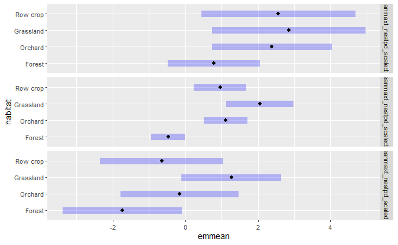

```r
emmeans(s_nestpd_WEBL_addmin,specs = pairwise ~ habitat,by = c("meanmaxt_nestpd_scaled"), at = list(meanmaxt_nestpd_scaled = c(-2,0,2))) %>% plot()
```

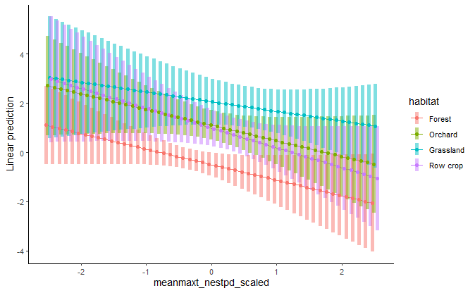

```r
emmip(s_nestpd_WEBL_addmin,formula = habitat ~ meanmaxt_nestpd_scaled, at = list(meanmaxt_nestpd_scaled = seq(from = -2.5, to = 2.5, by = .1)),CIs = TRUE, plotit = FALSE) %>% emmip_ggplot() + theme_classic()
```

## Emmeans to check for effect of habitat

```r
(t <- emmeans(s_nestpd_WEBL_addmin,"habitat") %>% pairs() %>% as_tibble() %>%
   mutate(across(estimate:z.ratio,~round(.x,digits = 2)),
          across(p.value,~round(.x,digits = 3))) %>% gt())
```

| contrast | estimate | SE | df | z.ratio | p.value |
| --- | --- | --- | --- | --- | --- |
| Forest - Orchard | -1.59 | 0.43 | Inf | -3.71 | 0.001 |
| Forest - Grassland | -2.53 | 0.53 | Inf | -4.76 | 0.000 |
| Forest - Row crop | -1.43 | 0.41 | Inf | -3.50 | 0.003 |
| Orchard - Grassland | -0.94 | 0.60 | Inf | -1.56 | 0.402 |
| Orchard - Row crop | 0.16 | 0.50 | Inf | 0.31 | 0.990 |
| Grassland - Row crop | 1.10 | 0.59 | Inf | 1.86 | 0.244 |

```r
gtsave(t,"../figures/survival_nestpd_byhabitat_webl.html")
```

Forest survival is lower than in the other land covers.

### Check for effect of temperature

```r
(t <- summary(s_nestpd_WEBL_noint) %>% coef() %>% as_tibble(rownames = "Covariate") %>%
   # dplyr::filter(Covariate != "poly(mean_temp_scaled, 2)1") %>%
   mutate(across(Estimate:`z value`,~round(.x,digits = 2)),
          across(`Pr(>|z|)`,~round(.x,digits = 3))) %>% gt())
```

| Covariate | Estimate | Std. Error | z value | Pr(>\|z\|) |
| --- | --- | --- | --- | --- |
| (Intercept) | 0.01 | 0.43 | 0.01 | 0.988 |
| meanmaxt_nestpd_scaled | -0.58 | 0.30 | -1.93 | 0.054 |
| meanmint_nestpd_scaled | 0.51 | 0.28 | 1.82 | 0.069 |
| habitatOrchard | 1.56 | 0.42 | 3.72 | 0.000 |
| habitatGrassland | 2.61 | 0.54 | 4.86 | 0.000 |
| habitatRow crop | 1.34 | 0.38 | 3.52 | 0.000 |
| juliandate_hatch_scaled | -0.08 | 0.28 | -0.29 | 0.770 |
| year_fct2022 | -0.33 | 0.38 | -0.86 | 0.390 |
| year_fct2023 | -1.10 | 0.49 | -2.22 | 0.026 |
| sitePG | 0.43 | 0.36 | 1.18 | 0.238 |
| siteRR | 0.35 | 0.41 | 0.85 | 0.397 |
| siteWI | -0.74 | 0.56 | -1.31 | 0.189 |

```r
gtsave(t,"../figures/survival_nestpd_byhabitat_summary_webl.html")
```

Hot temps and low temps reduce survival overall.

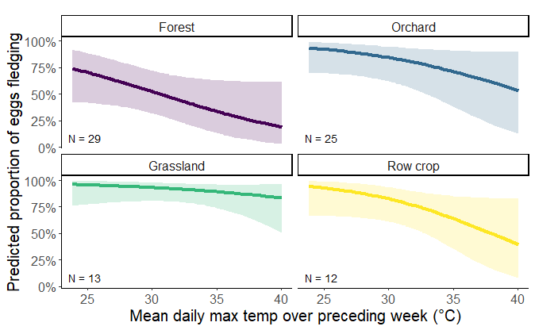

```r
data_webl = s_nestpd_WEBL_addmin$data


mean_temp_webl <- mean(data_webl %>% pull(meanmaxt_nestpd),na.rm = TRUE)
sd_temp_webl <- sd(data_webl %>% pull(meanmaxt_nestpd),na.rm = TRUE)


temp_trans_webl <- trans_new("temp_trans_webl",
                          transform = function(x){(x * sd_temp_webl) + mean_temp_webl},
                          inverse = function(x){x})

samp_webl <- data_webl %>% group_by(habitat) %>% summarize(count = n())
# samp %>% gt() %>% gtsave("../figures/ss_webl.html")
#
data_webl %>% group_by(habitat,year_fct) %>% summarize(count = n()) %>%
  pivot_wider(values_from = count,names_from = year_fct) %>% as.tibble() %>% rename(Habitat = 'habitat') %>% ungroup() %>% mutate(Total = `2021` + `2022` + `2023`) %>% gt() %>%
  grand_summary_rows(columns = -c(Habitat),fns = list(id = "Total") ~ sum(.)) %>%
  gtsave("../figures/ss_year_survival_webl.html")


dat_text_webl <- data.frame(
  label = paste("N =",samp_webl$count),
  group   = factor(samp_webl$habitat)
)

(fig3_webl <- predict_response(s_nestpd_WEBL_addmin,terms = c("meanmaxt_nestpd_scaled [all]","habitat")) %>%
   plot(line_size = 1.5,alpha = .2,show_data = TRUE,limit_range = TRUE) +
    theme_classic() +
   facet_wrap(~ group, ncol = 2) +
    xlab("Mean daily max temp over preceding week (\u00b0C)") +
    ylab("Predicted proportion of eggs fledging") +
   scale_fill_viridis(discrete = TRUE) +
    scale_color_viridis(discrete = TRUE) +
    theme(text = element_text(size = 16)) +
    labs(title = element_blank()) +
   scale_x_continuous(trans = temp_trans_webl,
                       breaks = c((20-mean_temp_webl)/sd_temp_webl,
                                  (25-mean_temp_webl)/sd_temp_webl,
                                  (30-mean_temp_webl)/sd_temp_webl,
                                  (35-mean_temp_webl)/sd_temp_webl,
                                  (40-mean_temp_webl)/sd_temp_webl#,
                                  #(45-mean_temp)/sd_temp
                                  ),
                       # breaks = c(20,30,40,50),
                       # labels = c("20","30","40","50"),
                       # limits = c((15-mean(g$meanmaxtempI,na.rm = TRUE))/sd(g$meanmaxtempI,na.rm = TRUE),
                       #            (55-mean(g$meanmaxtempI,na.rm = TRUE))/sd(g$meanmaxtempI,na.rm = TRUE))
                       # limits = c(18,5)
                       ) +
   # ylim(0,100) +
   geom_text(data = dat_text_webl, mapping = aes(x = -Inf, y = -Inf,label = label),hjust = -.2,vjust = -.7,inherit.aes = FALSE) +
    theme(legend.position = "none")
   )

ggsave("../figures/survbytempxhab_webl.png",fig3_webl,width = 10, height = 6.6)
```

### TRES

#### Incubation model

```r
s_inc_TRES <- glm(cbind(eggs_hatched,clutch_size - eggs_hatched) ~ meanmaxt_inc_scaled * habitat + meanmint_inc_scaled * habitat + juliandate_inc_scaled + year_fct + site,
               family = binomial(link = "logit"),
               data = dplyr::filter(s,
                                    Species == "TRES",
                                    !is.na(eggs_hatched),
                                    !is.na(clutch_size)) %>%
                 mutate(across(c(meanmaxt_inc,meanmint_inc,juliandate_inc),
                               ~ scale(.x)[,1],
                               .names = "{.col}_scaled")
                      )
               )

s_inc_TRES_addmax <- glm(cbind(eggs_hatched,clutch_size - eggs_hatched) ~ meanmaxt_inc_scaled + meanmint_inc_scaled * habitat + juliandate_inc_scaled + year_fct + site,
               family = binomial(link = "logit"),
               data = dplyr::filter(s,
                                    Species == "TRES",
                                    !is.na(eggs_hatched),
                                    !is.na(clutch_size)) %>%
                 mutate(across(c(meanmaxt_inc,meanmint_inc,juliandate_inc),
                               ~ scale(.x)[,1],
                               .names = "{.col}_scaled")
                      )
               )

s_inc_TRES_addmin <- glm(cbind(eggs_hatched,clutch_size - eggs_hatched) ~ meanmaxt_inc_scaled * habitat + meanmint_inc_scaled + juliandate_inc_scaled + year_fct + site,
               family = binomial(link = "logit"),
               data = dplyr::filter(s,
                                    Species == "TRES",
                                    !is.na(eggs_hatched),
                                    !is.na(clutch_size)) %>%
                 mutate(across(c(meanmaxt_inc,meanmint_inc,juliandate_inc),
                               ~ scale(.x)[,1],
                               .names = "{.col}_scaled")
                      )
               )
s_inc_TRES_noint <- glm(cbind(eggs_hatched,clutch_size - eggs_hatched) ~ meanmaxt_inc_scaled + meanmint_inc_scaled + habitat + juliandate_inc_scaled + year_fct + site,
               family = binomial(link = "logit"),
               data = dplyr::filter(s,
                                    Species == "TRES",
                                    !is.na(eggs_hatched),
                                    !is.na(clutch_size)) %>%
                 mutate(across(c(meanmaxt_inc,meanmint_inc,juliandate_inc),
                               ~ scale(.x)[,1],
                               .names = "{.col}_scaled")
                      )
               )

c1 <- anova(s_inc_TRES,s_inc_TRES_addmin,s_inc_TRES_noint) %>% tibble() %>% mutate(Model = c("no interaction","single interaction","both interacting"),.before = Df)

c2 <- anova(s_inc_TRES,s_inc_TRES_addmax,s_inc_TRES_noint) %>% tibble() %>% mutate(Model = c("no interaction","single interaction","both interacting"),.before = Df)

(tab <- bind_rows(c1,c2) %>%
  as_tibble() %>%
  mutate(across(where(is.numeric),~round(.x,digits = 4)),
         P = `Pr(>Chi)`) %>%
  dplyr::select(Model,Deviance,P) %>%
  mutate(max_or_min = c(rep("Max temp",times = 3),rep("Min temp",times = 3)),
         across(c(Deviance), ~ round(.x, digits = 2)),
         P = if_else(P < 0.001,"<0.001",as.character(P))) %>%
  group_by(max_or_min) %>% gt())
```

| Model | Deviance | P |
| --- | --- | --- |
| Max temp |  |  |
| no interaction | NA | NA |
| single interaction | -2.60 | 0.4583 |
| both interacting | -2.90 | 0.4076 |
| Min temp |  |  |
| no interaction | NA | NA |
| single interaction | -2.13 | 0.5458 |
| both interacting | -3.36 | 0.3389 |

```r
gtsave(tab,"../figures/int_tab_survival_tres.html")
```

Land cover does not interact with max or min temp during incubation.

```r
summary(s_inc_TRES_noint)
```

```
Call:
glm(formula = cbind(eggs_hatched, clutch_size - eggs_hatched) ~
    meanmaxt_inc_scaled + meanmint_inc_scaled + habitat + juliandate_inc_scaled +
        year_fct + site, family = binomial(link = "logit"), data = dplyr::filter(s,
    Species == "TRES", !is.na(eggs_hatched), !is.na(clutch_size)) %>%
    mutate(across(c(meanmaxt_inc, meanmint_inc, juliandate_inc),
        ~scale(.x)[, 1], .names = "{.col}_scaled")))

Coefficients:
                      Estimate Std. Error z value Pr(>|z|)
(Intercept)            1.66039    0.39172   4.239 2.25e-05 ***
meanmaxt_inc_scaled   -0.41101    0.18348  -2.240  0.02508 *
meanmint_inc_scaled    0.12351    0.26616   0.464  0.64262
habitatOrchard         0.10335    0.89881   0.115  0.90845
habitatGrassland       1.46968    0.49839   2.949  0.00319 **
habitatRow crop        0.94368    0.45561   2.071  0.03833 *
juliandate_inc_scaled  0.13742    0.25446   0.540  0.58917
year_fct2022          -0.13968    0.40524  -0.345  0.73033
year_fct2023          -0.30468    0.46696  -0.652  0.51410
sitePG                -0.42585    0.46820  -0.910  0.36307
siteRR                -0.74419    0.43268  -1.720  0.08544 .
siteWI                 0.08997    1.08625   0.083  0.93399
---
Signif. codes:  0 ‘***’ 0.001 ‘**’ 0.01 ‘*’ 0.05 ‘.’ 0.1 ‘ ’ 1

(Dispersion parameter for binomial family taken to be 1)

    Null deviance: 100.386  on 83  degrees of freedom
Residual deviance:  84.675  on 72  degrees of freedom
  (1 observation deleted due to missingness)
AIC: 176.08

Number of Fisher Scoring iterations: 5
```

However, there is a direct negative effect of high temps. Also, survival is generally higher in Grassland and Row crop than Forest.

```r
(t <- emmeans(s_inc_TRES_noint,"habitat") %>% pairs() %>% as_tibble() %>%
   mutate(across(estimate:z.ratio,~round(.x,digits = 2)),
          across(p.value,~round(.x,digits = 3))) %>% gt())
gtsave(t,"../figures/survival_inc_byhabitat_tres.html")
```

Posthoc test does not support the difference between row crop and forest?

```r
mean_temp <- mean(s_inc_TRES_noint$data %>% pull(meanmaxt_inc),na.rm = TRUE)
sd_temp <- sd(s_inc_TRES_noint$data %>% pull(meanmaxt_inc),na.rm = TRUE)


temp_trans <- trans_new("temp_trans",
                          transform = function(x){(x * sd_temp) + mean_temp},
                           inverse = function(x){x})

samp <- s_inc_TRES_noint$data %>% summarize(count = n())
# samp %>% gt() %>% gtsave("../figures/ss_TRES.html")


dat_text <- data.frame(
label = paste("N =",samp$count)
)



(pl <- predict_response(s_inc_TRES_noint,terms = c("meanmaxt_inc_scaled [all]")) %>%
   plot(line_size = 1.5,alpha = .2,show_data = TRUE,limit_range = TRUE) +
   theme_classic() +
   #facet_wrap(~ group, ncol = 2) +
    xlab("Mean daily max temp incubation to fledging (\u00b0C)") +
    ylab("Predicted proportion of eggs fledging") +
   # scale_fill_viridis(discrete = TRUE) +
   #  scale_color_viridis(discrete = TRUE) +
    theme(text = element_text(size = 16)) +
    labs(title = "TRES; linear max") +
   scale_x_continuous(trans = temp_trans,
                       breaks = c((20-mean_temp)/sd_temp,
                                  (25-mean_temp)/sd_temp,
                                  (30-mean_temp)/sd_temp,
                                  (35-mean_temp)/sd_temp,
                                  (40-mean_temp)/sd_temp#,
                                  #(45-mean_temp)/sd_temp
                                  ),
                       # breaks = c(20,30,40,50),
                       # labels = c("20","30","40","50"),
                       # limits = c((15-mean(g$meanmaxtempI,na.rm = TRUE))/sd(g$meanmaxtempI,na.rm = TRUE),
                       #            (55-mean(g$meanmaxtempI,na.rm = TRUE))/sd(g$meanmaxtempI,na.rm = TRUE))
                       # limits = c(18,5)
                       ) +
   # ylim(0,100) +
   geom_text(data = dat_text, mapping = aes(x = -Inf, y = -Inf,label = label),hjust = -.2,vjust = -.7,inherit.aes = FALSE) +
    theme(legend.position = "none")
 )
```

```r
samp <- s_inc_TRES_noint$data %>% group_by(habitat) %>% summarize(count = n())
# samp %>% gt() %>% gtsave("../figures/ss_TRES.html")


dat_text <- data.frame(
label = paste("N =",samp$count),
group = factor(samp$habitat)
)



dat <- predict_response(s_inc_TRES_noint,terms = c("habitat"))

(pl <- ggplot(data = dat, mapping = aes(x = x, color = x, y = predicted,ymin = conf.low,ymax = conf.high)) +
   # plot(line_size = 1.5,alpha = .2,show_data = TRUE,limit_range = TRUE,colors = viridis(4)) +
   geom_point(size = 4) +
    geom_linerange(linewidth = 2) +
   theme_classic() +
   #facet_wrap(~ group, ncol = 2) +
    xlab("Land cover") +
    ylab("Predicted proportion of eggs fledging") +
   # scale_fill_viridis(discrete = TRUE) +
   scale_color_manual(values = viridis(4)) +
    theme(text = element_text(size = 16)) +
    labs(title = "TRES; linear max") +
   # scale_x_continuous(trans = temp_trans,
   #                     breaks = c((20-mean_temp)/sd_temp,
   #                                (25-mean_temp)/sd_temp,
   #                                (30-mean_temp)/sd_temp,
   #                                (35-mean_temp)/sd_temp,
   #                                (40-mean_temp)/sd_temp#,
   #                                #(45-mean_temp)/sd_temp
   #                                ),
   #                     # breaks = c(20,30,40,50),
   #                     # labels = c("20","30","40","50"),
   #                     # limits = c((15-mean(g$meanmaxtempI,na.rm = TRUE))/sd(g$meanmaxtempI,na.rm = TRUE),
   #                     #            (55-mean(g$meanmaxtempI,na.rm = TRUE))/sd(g$meanmaxtempI,na.rm = TRUE))
   #                     # limits = c(18,5)
   #                     ) +
   # ylim(0,100) +
   geom_text(data = dat_text, mapping = aes(x = c(1,2,3,4), y = -Inf,label = label),hjust = .5,vjust = -.7,inherit.aes = FALSE) +
    theme(legend.position = "none") +
    annotate(geom = "text", x = c(1,2,3,4),y = Inf,hjust = .5,vjust = 1,label = c("a","ab","b","ab"))
 )
```

#### Nestling model

```r
s_nest_TRES <- glm(cbind(nest_fledged,brood_size - nest_fledged) ~ meanmaxt_nest_scaled * habitat + meanmint_nest_scaled * habitat + juliandate_hatch_scaled + year_fct + site,
               family = binomial(link = "logit"),
               data = dplyr::filter(s,
                                    Species == "TRES",
                                    !is.na(nest_fledged),
                                    !is.na(brood_size)) %>%
                 mutate(across(c(meanmaxt_nest,meanmint_nest,juliandate_hatch),
                               ~ scale(.x)[,1],
                               .names = "{.col}_scaled")
                      )
               )

s_nest_TRES_addmax <- glm(cbind(nest_fledged,brood_size - nest_fledged) ~ meanmaxt_nest_scaled + meanmint_nest_scaled * habitat + juliandate_hatch_scaled + year_fct + site,
               family = binomial(link = "logit"),
               data = dplyr::filter(s,
                                    Species == "TRES",
                                    !is.na(nest_fledged),
                                    !is.na(brood_size)) %>%
                 mutate(across(c(meanmaxt_nest,meanmint_nest,juliandate_hatch),
                               ~ scale(.x)[,1],
                               .names = "{.col}_scaled")
                      )
               )

s_nest_TRES_addmin <- glm(cbind(nest_fledged,brood_size - nest_fledged) ~ meanmaxt_nest_scaled * habitat + meanmint_nest_scaled + juliandate_hatch_scaled + year_fct + site,
               family = binomial(link = "logit"),
               data = dplyr::filter(s,
                                    Species == "TRES",
                                    !is.na(nest_fledged),
                                    !is.na(brood_size)) %>%
                 mutate(across(c(meanmaxt_nest,meanmint_nest,juliandate_hatch),
                               ~ scale(.x)[,1],
                               .names = "{.col}_scaled")
                      )
               )
s_nest_TRES_noint <- glm(cbind(nest_fledged,brood_size - nest_fledged) ~ meanmaxt_nest_scaled + meanmint_nest_scaled + habitat + juliandate_hatch_scaled + year_fct + site,
               family = binomial(link = "logit"),
               data = dplyr::filter(s,
                                    Species == "TRES",
                                    !is.na(nest_fledged),
                                    !is.na(brood_size)) %>%
                 mutate(across(c(meanmaxt_nest,meanmint_nest,juliandate_hatch),
                               ~ scale(.x)[,1],
                               .names = "{.col}_scaled")
                      )
               )

c1 <- anova(s_nest_TRES,s_nest_TRES_addmin,s_nest_TRES_noint) %>% tibble() %>% mutate(Model = c("no interaction","single interaction","both interacting"),.before = Df)

c2 <- anova(s_nest_TRES,s_nest_TRES_addmax,s_nest_TRES_noint) %>% tibble() %>% mutate(Model = c("no interaction","single interaction","both interacting"),.before = Df)

(tab <- bind_rows(c1,c2) %>%
  as_tibble() %>%
  mutate(across(where(is.numeric),~round(.x,digits = 4)),
         P = `Pr(>Chi)`) %>%
  dplyr::select(Model,Deviance,P) %>%
  mutate(max_or_min = c(rep("Max temp",times = 3),rep("Min temp",times = 3)),
         across(c(Deviance), ~ round(.x, digits = 2)),
         P = if_else(P < 0.001,"<0.001",as.character(P))) %>%
  group_by(max_or_min) %>% gt())
gtsave(tab,"../figures/int_tab_survival_nest_tres.html")
```

For TRES nestlings, neither max nor mean temp interacts with land cover.

```r
summary(s_nest_TRES_noint)
```

No main effects of temp but potentially main effects of habitat- yes, grassland and row crop have higher survival than forest.

```r
(t <- emmeans(s_nest_TRES_noint,"habitat") %>% pairs() %>% as_tibble() %>%
   mutate(across(estimate:z.ratio,~round(.x,digits = 2)),
          across(p.value,~round(.x,digits = 3))) %>% gt())
gtsave(t,"../figures/survival_nest_byhabitat_tres.html")
```

```r
samp <- s_nest_TRES_noint$data %>% group_by(habitat) %>% summarize(count = n())
# samp %>% gt() %>% gtsave("../figures/ss_TRES.html")


dat_text <- data.frame(
label = paste("N =",samp$count),
group = factor(samp$habitat)
)



dat <- predict_response(s_nest_TRES_noint,terms = c("habitat"))

(pl <- ggplot(data = dat, mapping = aes(x = x, color = x, y = predicted,ymin = conf.low,ymax = conf.high)) +
   # plot(line_size = 1.5,alpha = .2,show_data = TRUE,limit_range = TRUE,colors = viridis(4)) +
   geom_point(size = 4) +
    geom_linerange(linewidth = 2) +
   theme_classic() +
   #facet_wrap(~ group, ncol = 2) +
    xlab("Land cover") +
    ylab("Predicted proportion of nestlings fledging") +
   # scale_fill_viridis(discrete = TRUE) +
   scale_color_manual(values = viridis(4)) +
    theme(text = element_text(size = 16)) +
    labs(title = "TRES; linear max") +
   # scale_x_continuous(trans = temp_trans,
   #                     breaks = c((20-mean_temp)/sd_temp,
   #                                (25-mean_temp)/sd_temp,
   #                                (30-mean_temp)/sd_temp,
   #                                (35-mean_temp)/sd_temp,
   #                                (40-mean_temp)/sd_temp#,
   #                                #(45-mean_temp)/sd_temp
   #                                ),
   #                     # breaks = c(20,30,40,50),
   #                     # labels = c("20","30","40","50"),
   #                     # limits = c((15-mean(g$meanmaxtempI,na.rm = TRUE))/sd(g$meanmaxtempI,na.rm = TRUE),
   #                     #            (55-mean(g$meanmaxtempI,na.rm = TRUE))/sd(g$meanmaxtempI,na.rm = TRUE))
   #                     # limits = c(18,5)
   #                     ) +
   ylim(0,1.1) +
   geom_text(data = dat_text, mapping = aes(x = c(1,2,3,4), y = -Inf,label = label),hjust = .5,vjust = -1,inherit.aes = FALSE) +
    theme(legend.position = "none") +
    annotate(geom = "text", x = c(1,2,3,4),y = Inf,hjust = .5,vjust = 1,label = c("a","ab","b","b"))
 )
```

#### Nest period model

```r
s_nestpd_TRES <- glm(cbind(nest_fledged,clutch_size - nest_fledged) ~ meanmaxt_nestpd_scaled * habitat + meanmint_nestpd_scaled * habitat + juliandate_hatch_scaled + year_fct + site,
               family = binomial(link = "logit"),
               data = dplyr::filter(s,
                                    Species == "TRES",
                                    !is.na(nest_fledged),
                                    !is.na(clutch_size)) %>%
                 mutate(across(c(meanmaxt_nestpd,meanmint_nestpd,juliandate_hatch),
                               ~ scale(.x)[,1],
                               .names = "{.col}_scaled")
                      )
               )

s_nestpd_TRES_addmax <- glm(cbind(nest_fledged,clutch_size - nest_fledged) ~ meanmaxt_nestpd_scaled + meanmint_nestpd_scaled * habitat + juliandate_hatch_scaled + year_fct + site,
               family = binomial(link = "logit"),
               data = dplyr::filter(s,
                                    Species == "TRES",
                                    !is.na(nest_fledged),
                                    !is.na(clutch_size)) %>%
                 mutate(across(c(meanmaxt_nestpd,meanmint_nestpd,juliandate_hatch),
                               ~ scale(.x)[,1],
                               .names = "{.col}_scaled")
                      )
               )

s_nestpd_TRES_addmin <- glm(cbind(nest_fledged,clutch_size - nest_fledged) ~ meanmaxt_nestpd_scaled * habitat + meanmint_nestpd_scaled + juliandate_hatch_scaled + year_fct + site,
               family = binomial(link = "logit"),
               data = dplyr::filter(s,
                                    Species == "TRES",
                                    !is.na(nest_fledged),
                                    !is.na(clutch_size)) %>%
                 mutate(across(c(meanmaxt_nestpd,meanmint_nestpd,juliandate_hatch),
                               ~ scale(.x)[,1],
                               .names = "{.col}_scaled")
                      )
               )
s_nestpd_TRES_noint <- glm(cbind(nest_fledged,clutch_size - nest_fledged) ~ meanmaxt_nestpd_scaled + meanmint_nestpd_scaled + habitat + juliandate_hatch_scaled + year_fct + site,
               family = binomial(link = "logit"),
               data = dplyr::filter(s,
                                    Species == "TRES",
                                    !is.na(nest_fledged),
                                    !is.na(clutch_size)) %>%
                 mutate(across(c(meanmaxt_nestpd,meanmint_nestpd,juliandate_hatch),
                               ~ scale(.x)[,1],
                               .names = "{.col}_scaled")
                      )
               )

c1 <- anova(s_nestpd_TRES,s_nestpd_TRES_addmin,s_nestpd_TRES_noint) %>% tibble() %>% mutate(Model = c("no interaction","single interaction","both interacting"),.before = Df)

c2 <- anova(s_nestpd_TRES,s_nestpd_TRES_addmax,s_nestpd_TRES_noint) %>% tibble() %>% mutate(Model = c("no interaction","single interaction","both interacting"),.before = Df)

(tab <- bind_rows(c1,c2) %>%
  as_tibble() %>%
  mutate(across(where(is.numeric),~round(.x,digits = 4)),
         P = `Pr(>Chi)`) %>%
  dplyr::select(Model,Deviance,P) %>%
  mutate(max_or_min = c(rep("Max temp",times = 3),rep("Min temp",times = 3)),
         across(c(Deviance), ~ round(.x, digits = 2)),
         P = if_else(P < 0.001,"<0.001",as.character(P))) %>%
  group_by(max_or_min) %>% gt())
```

| Model | Deviance | P |
| --- | --- | --- |
| Max temp |  |  |
| no interaction | NA | NA |
| single interaction | -3.40 | 0.3339 |
| both interacting | -4.24 | 0.2362 |
| Min temp |  |  |
| no interaction | NA | NA |
| single interaction | -4.93 | 0.1773 |
| both interacting | -2.72 | 0.4369 |

```r
gtsave(tab,"../figures/int_tab_survival_nestpd_tres.html")
```

No interaction of land cover with max or min temp for TRES nest period.

```r
summary(s_nestpd_TRES_noint)
```

```
Call:
glm(formula = cbind(nest_fledged, clutch_size - nest_fledged) ~
    meanmaxt_nestpd_scaled + meanmint_nestpd_scaled + habitat +
        juliandate_hatch_scaled + year_fct + site, family = binomial(link = "logit"),
    data = dplyr::filter(s, Species == "TRES", !is.na(nest_fledged),
        !is.na(clutch_size)) %>% mutate(across(c(meanmaxt_nestpd,
        meanmint_nestpd, juliandate_hatch), ~scale(.x)[, 1],
        .names = "{.col}_scaled")))

Coefficients:
                        Estimate Std. Error z value Pr(>|z|)
(Intercept)              0.20651    0.33367   0.619  0.53598
meanmaxt_nestpd_scaled   0.04199    0.23004   0.183  0.85516
meanmint_nestpd_scaled   0.23157    0.26758   0.865  0.38681
habitatOrchard           0.44313    0.86985   0.509  0.61045
habitatGrassland         1.44307    0.48850   2.954  0.00314 **
habitatRow crop          1.08659    0.41326   2.629  0.00856 **
juliandate_hatch_scaled -0.54721    0.25892  -2.113  0.03457 *
year_fct2022             0.48770    0.34364   1.419  0.15584
year_fct2023             0.83261    0.44767   1.860  0.06291 .
sitePG                  -0.13315    0.39842  -0.334  0.73823
siteRR                  -0.76134    0.40205  -1.894  0.05827 .
siteWI                  -1.55570    1.01106  -1.539  0.12388
---
Signif. codes:  0 ‘***’ 0.001 ‘**’ 0.01 ‘*’ 0.05 ‘.’ 0.1 ‘ ’ 1

(Dispersion parameter for binomial family taken to be 1)

    Null deviance: 181.27  on 64  degrees of freedom
Residual deviance: 138.59  on 53  degrees of freedom
AIC: 228.39

Number of Fisher Scoring iterations: 5
```

No main effects of max or min temp. Effects of habitat?

```r
(t <- emmeans(s_nestpd_TRES_noint,"habitat") %>% pairs() %>% as_tibble() %>%
   mutate(across(estimate:z.ratio,~round(.x,digits = 2)),
          across(p.value,~round(.x,digits = 3))) %>% gt())
```

| contrast | estimate | SE | df | z.ratio | p.value |
| --- | --- | --- | --- | --- | --- |
| Forest - Orchard | -0.44 | 0.87 | Inf | -0.51 | 0.957 |
| Forest - Grassland | -1.44 | 0.49 | Inf | -2.95 | 0.017 |
| Forest - Row crop | -1.09 | 0.41 | Inf | -2.63 | 0.043 |
| Orchard - Grassland | -1.00 | 0.78 | Inf | -1.28 | 0.573 |
| Orchard - Row crop | -0.64 | 0.80 | Inf | -0.80 | 0.855 |
| Grassland - Row crop | 0.36 | 0.42 | Inf | 0.84 | 0.834 |

```r
gtsave(t,"../figures/survival_nestpd_byhabitat_tres.html")
```

Yes - survival is higher in grassland and row crop than in forest.

[output not shown]

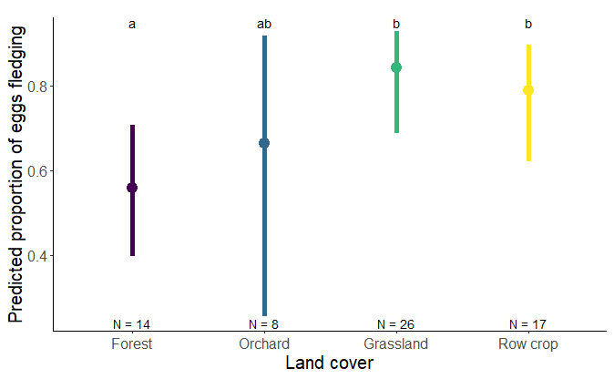

```r
samp_tres <- s_nestpd_TRES_noint$data %>% group_by(habitat) %>% summarize(count = n())
# samp %>% gt() %>% gtsave("../figures/ss_TRES.html")
s_nestpd_TRES_noint$data %>% group_by(habitat,year_fct) %>% summarize(count = n()) %>%
  pivot_wider(values_from = count,names_from = year_fct) %>% as.tibble() %>% rename(Habitat = 'habitat') %>% ungroup() %>% mutate(Total = `2021` + `2022` + `2023`) %>% gt() %>%
  grand_summary_rows(columns = -c(Habitat),fns = list(id = "Total") ~ sum(.)) %>%
  gtsave("../figures/ss_year_survival_tres.html")


dat_text_tres <- data.frame(
label = paste("N =",samp_tres$count),
group = factor(samp_tres$habitat)
)



dat_tres <- predict_response(s_nestpd_TRES_noint,terms = c("habitat"))

(fig3_tres <- ggplot(data = dat_tres, mapping = aes(x = x, color = x, y = predicted,ymin = conf.low,ymax = conf.high)) +
   # plot(line_size = 1.5,alpha = .2,show_data = TRUE,limit_range = TRUE,colors = viridis(4)) +
   geom_point(size = 4) +
    geom_linerange(linewidth = 2) +
   theme_classic() +
   #facet_wrap(~ group, ncol = 2) +
    xlab("Land cover") +
    ylab("Predicted proportion of eggs fledging") +
   # scale_fill_viridis(discrete = TRUE) +
   scale_color_manual(values = viridis(4)) +
    theme(text = element_text(size = 16)) +
    labs(title = element_blank()) +
   # scale_x_continuous(trans = temp_trans,
   #                     breaks = c((20-mean_temp)/sd_temp,
   #                                (25-mean_temp)/sd_temp,
   #                                (30-mean_temp)/sd_temp,
   #                                (35-mean_temp)/sd_temp,
   #                                (40-mean_temp)/sd_temp#,
   #                                #(45-mean_temp)/sd_temp
   #                                ),
   #                     # breaks = c(20,30,40,50),
   #                     # labels = c("20","30","40","50"),
   #                     # limits = c((15-mean(g$meanmaxtempI,na.rm = TRUE))/sd(g$meanmaxtempI,na.rm = TRUE),
   #                     #            (55-mean(g$meanmaxtempI,na.rm = TRUE))/sd(g$meanmaxtempI,na.rm = TRUE))
   #                     # limits = c(18,5)
   #                     ) +
   # ylim(0,1.1) +
   geom_text(data = dat_text_tres, mapping = aes(x = c(1,2,3,4), y = -Inf,label = label),hjust = .5,vjust = -.2,inherit.aes = FALSE) +
    theme(legend.position = "none") +
    annotate(geom = "text", x = c(1,2,3,4),y = Inf,hjust = .5,vjust = 1,label = c("a","ab","b","b"))
 )

ggsave("../figures/survbytempxhab_tres.png",fig3_tres,width = 10, height = 6.6)
```